# Protest Arrests and Public Amenities, Summer 2020 New York City

Madeleine Levin, Jaida Nabayan, Michael Zajakowski Uhll

11/30/2021

# Introduction and Research question

We were initially interested in the relationships between social movements and the built environment. We decided to examine the Summer 2020 racial justice protests in New York City, as we had personal experience and memories of these protests. Protests are spatially facilitated and bounded, and we wanted to determine the exact elements of urban space that constitute this facilitation or discouragement. The most obvious seemed to be parks - they provide ample open space for large groups to organize and gather. Our question became “What is the relationship between the presence of open space and other amenities in NYC neighborhoods and the number of people arrested during protests against police brutality in summer 2020?” We hypothesized that the presence of parks would increase the number of protest related arrests, as large groups of people would be gathering in parks during the protests and thus be more likely to be arrested at the protest. We also decided to incorporate other urban space/amenity variables to inform a broader analysis of urban space and social movements.

# Background

While there is not a lot of quantitative research exploring the relationship between open space and protest in summer 2020, Rafail (2018) found that in NYC protests between 1960 and 2006, “the built environment, and the social relationships creating it, powerfully influence where dissent occurs.” Rafail finds that Privately Owned Public Spaces (POPs) are increasingly sites of gathering and protest, reflecting decentralization of public gathering spaces.Looking at the protests following George Floyd’s death in 2020, The US Crisis Monitor collected data on the political demonstrations that took place during from May - August 2020, with substantial focus on Black Lives Matter (BLM) protests throughout the United States. Their maps show the spatial concentration of protests in urban centers and that the majority of gatherings were protests and not riots (though they do not provide a clear definition explaining the difference between a riot and protest).

# Data

The sample population for this study is the entire citizen population of New York City in the summer of 2020. The analysis includes the following variables:

Variables are aggregated to the census tract level

Continuous

- NYC Arrests for Summer 2020 for “Resisting Arrest”
- All NYC Arrests in Summer 2020
- Number of Parks
- Number of POPS (privately owned public spaces)
- Number of Subway Stations
- Number of Museums
- Number of Historic Buildings (designated by the Landmarks Preservation Commission)
- Number of Public Wi-Fi Locations

Categorical

- NYC Borough of Arrest
- Does the Census Tract have a POPS (True or False)
- Does the Census Tract have a Library (True or False)

Arrest Description Used as Proxy for Protest Arrests:

- OFFENSES AGAINST PUBLIC ADMININISTRATION (RESISTING ARREST)

# Methods

We used a multivariate regression to show the effect of each variable on the number of resisting arrest charges in that census tract. We then graphed the variables with the most significant correlation to give a visual representation of our findings and facilitate quicker analysis.

# Results

## Number of Resisting Arrest Charges Per Borough

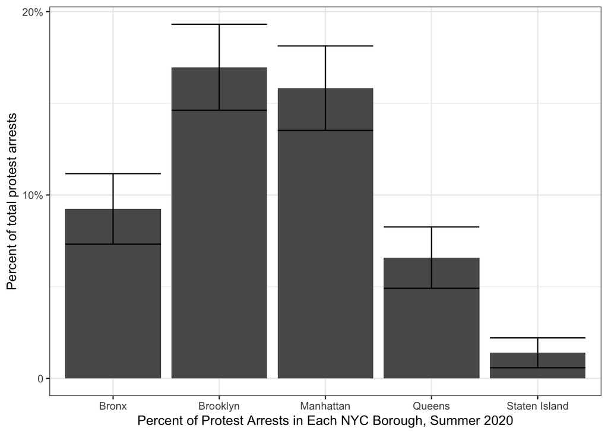

```r
ggplot(PCT_summary_arrests) +
  geom_bar(aes(x = `Percent of Protest Arrests in Each NYC Borough, Summer 2020`,
               y = `Sample proportion`),
           stat = "identity") +
  geom_errorbar(aes(x = `Percent of Protest Arrests in Each NYC Borough, Summer 2020`,
               y = `Sample proportion`,
               ymin = `95-percent confidence - low`,
               ymax = `95-percent confidence - high`),
           stat = "identity") +
  scale_y_continuous(name = "Percent of total protest arrests",
                     breaks = c(0, 20, 40, 60, 80),
                     labels = c("0", "10%", "20%", "30%", "40%")) +
  theme_bw()
```

## Map of Resisting Arrest Charges (Summer 2020)

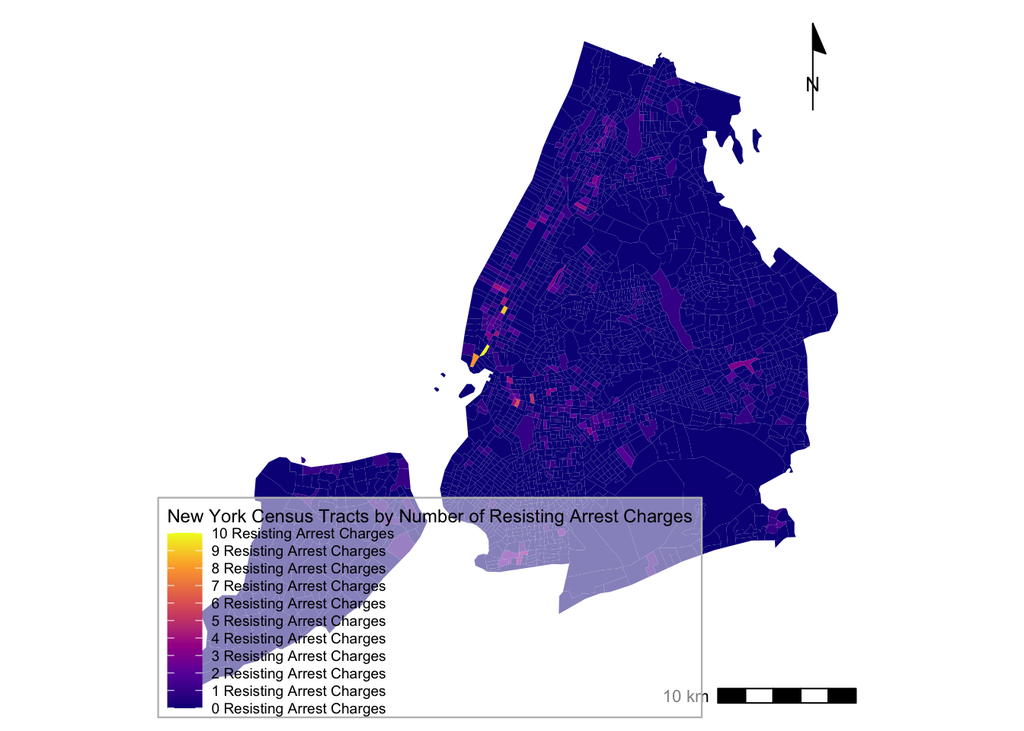

```r
ggplot(census2020) +
  geom_sf(color = NA,
          aes(fill = num_arrests)) +
  scale_fill_viridis_c(option = "C", name = "New York Census Tracts by Number of Resisting Arrest Charges",
                       breaks = breaks <- seq(0, 10, by = 1),
                       labels = paste(prettyNum(breaks, big.mark = ","),
                                      "Resisting Arrest Charges")) +
  annotation_scale(location = "br") +
  annotation_north_arrow(location = "tr",
                         style = north_arrow_minimal()) +
theme_map() +
  theme(legend.background = element_rect(fill = alpha("white", 0.5),
                                         color = "gray"))
```

## Map of All Arrests (Summer 2020)

[figure not shown]

```r
ggplot(census2020) +
  geom_sf(color = NA,
          aes(fill = allarrestssummer)) +
  scale_fill_viridis_c(option = "C", name = "New York Census Tracts by Number of Resisting Arrest Charges",
                       breaks = breaks <- seq(0, 500, by = 50),
                       labels = paste(prettyNum(breaks, big.mark = ","),
                                      "Resisting Arrest Charges")) +
  annotation_scale(location = "br") +
  annotation_north_arrow(location = "tr",
                         style = north_arrow_minimal()) +
theme_map() +
  theme(legend.background = element_rect(fill = alpha("white", 0.5),
                                         color = "gray"))
```

## Multivariate Regression

This model shows the impact that each variable had on the number of resisting arrest charges while holding all other variables constant. While we did try a number of scaling and centering transformations on this regression, none ultimately made a large difference in the output and the model fit remained similar between versions as well.

```r
full_model3 <- lm(num_arrests ~ num_parks + pop + num_subway + POPS_true + library_true + num_wifi +  num_museum + num_historic,census2020)

export_summs(full_model3,
             error_format = "(p = {p.value})",
             error_pos = "same",
             model.names = c("Multivariate Regression"))
```

|  | Multivariate Regression |
| --- | --- |
| (Intercept) | 0.02 (p = 0.41) |
| num_parks | 0.00 (p = 0.40) |
| pop | 0.00 * (p = 0.01) |
| num_subway | 0.09 *** (p = 0.00) |
| POPS_trueTrue | -0.02 (p = 0.79) |
| library_trueTrue | -0.01 (p = 0.82) |
| num_wifi | 0.01 (p = 0.05) |
| num_museum | -0.02 (p = 0.68) |
| num_historic | 0.00 * (p = 0.01) |
| N | 2327 |
| R2 | 0.11 |
| *** p < 0.001; ** p < 0.01; * p < 0.05. |  |

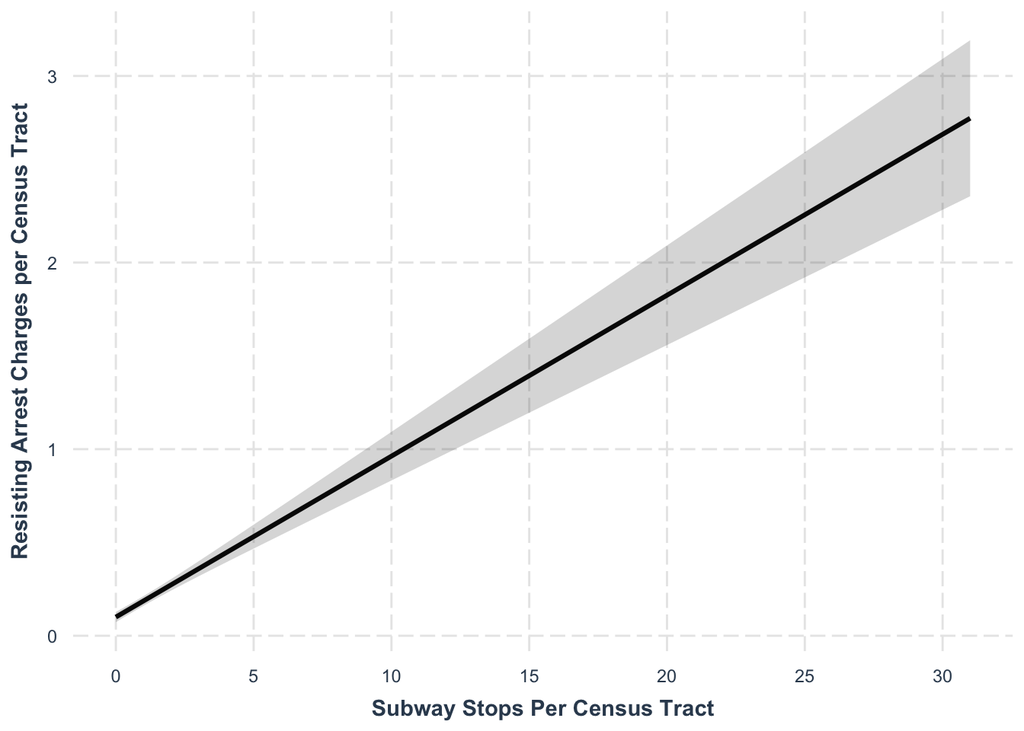

```r
effect_plot(full_model3, pred = num_subway, interval = TRUE) +
  scale_y_continuous(name = "Resisting Arrest Charges per Census Tract") +
  scale_x_continuous(name = "Subway Stops Per Census Tract",
                     breaks = breaks <- seq(0, 30, by = 5),
                     labels = prettyNum(breaks, big.mark = ","))
```

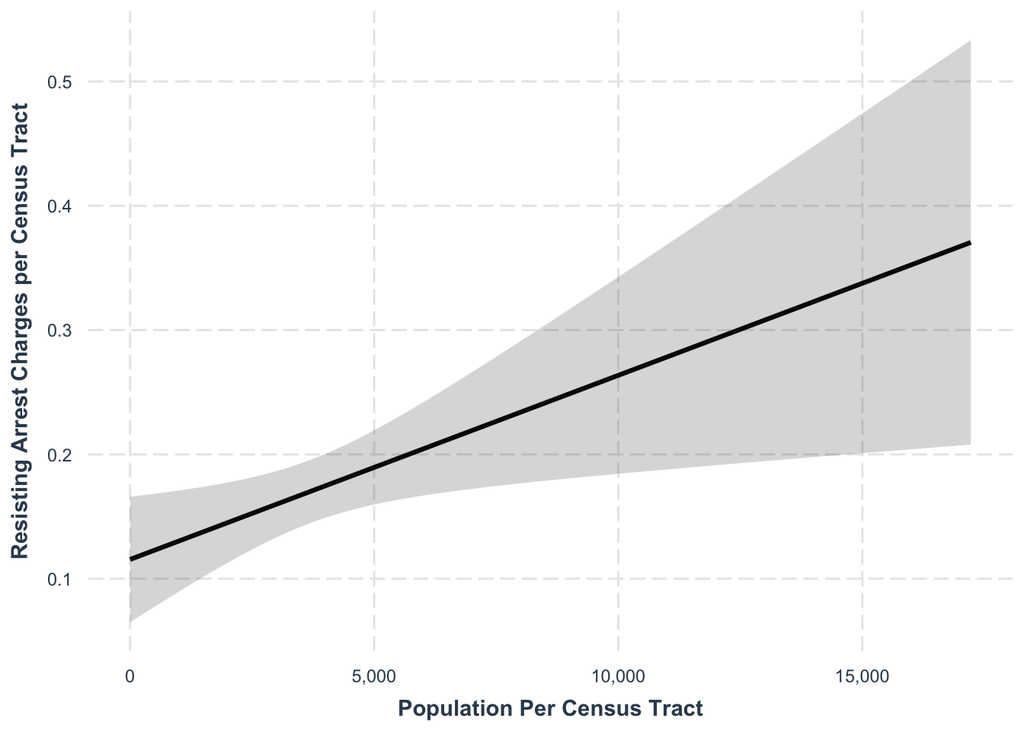

```r
effect_plot(full_model3, pred = pop, interval = TRUE) +
  scale_y_continuous(name = "Resisting Arrest Charges per Census Tract") +
  scale_x_continuous(name = "Population Per Census Tract",
                     breaks = breaks <- seq(0, 20000, by = 5000),
                     labels = prettyNum(breaks, big.mark = ","))
```

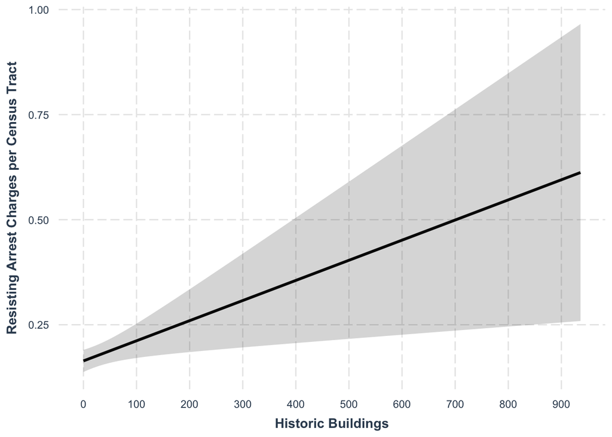

```r
effect_plot(full_model3, pred = num_historic, interval = TRUE) +
  scale_y_continuous(name = "Resisting Arrest Charges per Census Tract") +
  scale_x_continuous(name = "Historic Buildings",
                     breaks = breaks <- seq(0, 1000, by = 100),
                     labels = prettyNum(breaks, big.mark = ","))
```

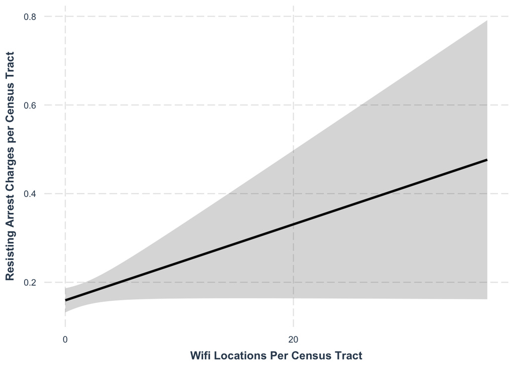

```r
effect_plot(full_model3, pred = num_wifi, interval = TRUE) +
  scale_y_continuous(name = "Resisting Arrest Charges per Census Tract") +
  scale_x_continuous(name = "Wifi Locations Per Census Tract",
                     breaks = breaks <- seq(0, 100, by = 20),
                     labels = prettyNum(breaks, big.mark = ","))
```

## Multivariate Regression with Interactions

```r
coeff_names_interaction <- c("Constant" = "(Intercept)",
                 "Number of Wifi Spots" = "census2020$num_wifi",
                 "Number of Historic Sites" = "census2020$num_historic",
                 "Number of Parks" = "census2020$num_parks",
                 "Number of Subways" = "census2020$num_subway",
                 "Number of Museums" = "census2020$num_museum",
                 "Resisting Arrests Charges" = "census2020$num_arrests",
                 "Population in 2020" = "census2020$pop",
                 "Has a POPS" = "census2020$POPS_trueTrue")


interaction_model <- lm(num_arrests ~ num_subway + pop + num_parks + num_historic + num_wifi + num_museum + POPS_true + library_true + num_subway*POPS_true,  census2020)

export_summs(full_model3, interaction_model,
             error_format = "(p = {p.value})",
             error_pos = "same",
             model.names = c("Original Data",
                             "Data with Interaction"))
```

|  | Original Data | Data with Interaction |
| --- | --- | --- |
| (Intercept) | 0.02 (p = 0.41) | 0.02 (p = 0.33) |
| num_parks | 0.00 (p = 0.40) | 0.00 (p = 0.22) |
| pop | 0.00 * (p = 0.01) | 0.00 ** (p = 0.00) |
| num_subway | 0.09 *** (p = 0.00) | 0.05 *** (p = 0.00) |
| POPS_trueTrue | -0.02 (p = 0.79) | -0.18 ** (p = 0.01) |
| library_trueTrue | -0.01 (p = 0.82) | -0.00 (p = 0.95) |
| num_wifi | 0.01 (p = 0.05) | 0.01 (p = 0.07) |
| num_museum | -0.02 (p = 0.68) | -0.02 (p = 0.61) |
| num_historic | 0.00 * (p = 0.01) | 0.00 ** (p = 0.00) |
| num_subway:POPS_trueTrue |  | 0.07 *** (p = 0.00) |
| N | 2327 | 2327 |
| R2 | 0.11 | 0.12 |
| *** p < 0.001; ** p < 0.01; * p < 0.05. |  |  |

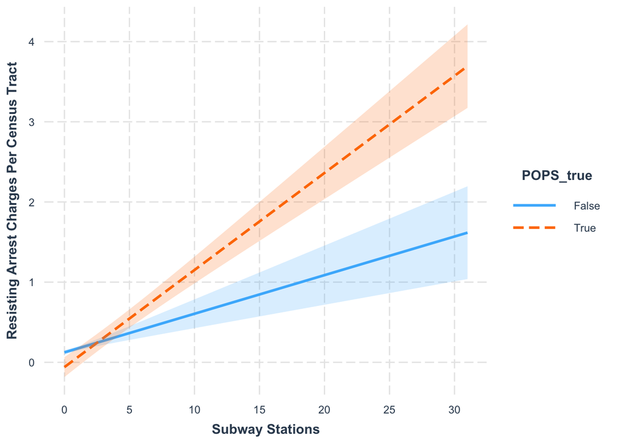

```r
interact_plot(interaction_model, pred = num_subway, modx = POPS_true,
              interval = TRUE) +
  scale_x_continuous(breaks = breaks <- c( 0, 5, 10, 15, 20, 25, 30),
                     labels = round(breaks),
                     name = "Subway Stations") +
  scale_y_continuous(name = "Resisting Arrest Charges Per Census Tract")
```

# Discussion

Ultimately, our hypothesis that parks would have a significant positive correlation to the number of protest arrests was incorrect, although we did find significant positive correlations with other urban amnenities.

## Multivariate Regression Discussion

Our R-Squared value for this regression is .11, suggesting that this model explains about 11% of Resisting Arrest charges in NYC in Summer 2020.

# Conclusion

We have a number of theories about our results. We may have overestimated the importance of parks in protest movements: as parks are always publicly accessible, they may not have as much of an insurrectionist character as gathering in a street or government building, and many protests seek to make their point by “laying claim” to spaces from which they are usually excluded.

The correlation between protest arrests and subway stations infers that perhaps what is most important to social movements is accessibility to and from other areas of the region, as people often travel to other neighborhoods to take part in protests.

The correlation between historic buildings and protest arrests infers that a) the majority of protests took place in Brooklyn and Manhattan which have a higher percentage of historic buildings than the other boroughs and b) that historic buildings, such as municipal buildings, have a monumental character that makes them attractive to symbolic expressions of social movement power.

# References

Rafail, Patrick. “Protest in the City: Urban Spatial Restructuring and Dissent in New York, 1960–2006.” Urban Studies 55, no. 1 (January 2018): 244–60. https://doi.org/10.1177/0042098016661464.

Armed Conflict Location & Event Data Project (ACLED), The US Crisis Monitor, 2020 https://acleddata.com/acleddatanew/wp-content/uploads/2020/09/ACLED_USDataReview_Sum2020_SeptWebPDF_HiRes.pdf